# Assignment1_PO

Peter Omasta

1/30/2020

### Task 1

#### **Part 1: Introduction**

The data was collected from 1998 - 2012 at the Bonanza Creek Experimental Forest inside of the Bonanza Creek LTER just outside Fairbanks, Alaska [3]. Snowshoe hares (*Lepus americanus*) are a well documented species that observe a 10 year cycle of population growth and decline [1,2]. This data set will examine to see whether this population of snowshoe hares in the Bonanza Creek LTER also observe a similar 10 year trend. We will explore the weight of both male and females inside of the population to see if there are trends that overlap with the ten year cycle of reproduction.

#### **Part 2: Images**

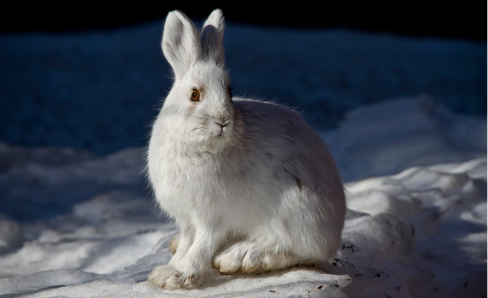

Source: Denali National Park and Preserve.

[figure not shown]

Source: University of Alaska Fairbanks.

#### **Part 3: Graph and Table**

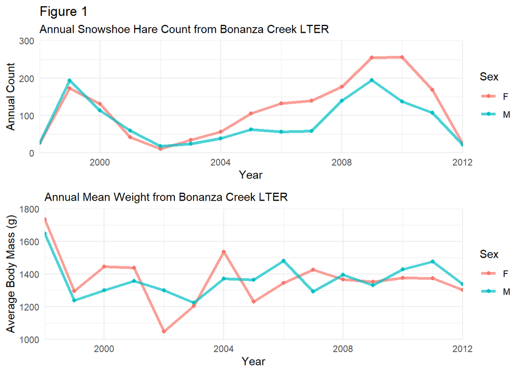

Figure 1: Displays the annual count and average weight in both male and female snowshoe hares from the Bonanza Creek LTER from 1998 to 2012. 3380 observations were collected over the course of the study but only 2987 are depicted on the graph. Data not included contains individuals that were captured whose sex was not recorded or was unknown.

**Discussion:**

The findings of this survey show a consistent trend that has been documented in previous studies (O’Donoghue, M. & Krebs, 1992; Belovsky, 1984) where snowshoe hares operate on a ten year population cycle. The population crashed in 2002 from a high in 1999, it then reached a new high in 2009 before crashing in 2012 again. Both genders follow this trend across years. While males have a relatively consistent weight, the females have a low mean weight in 2002, which may indicate a reason for why the population crashed. Lower physical health, interpreted by birth weight, may have resulted in lower birth rates. As female weights rebounded, the counts of snowshoe hares also increased, indicating that the health of female hares may be critical to maintaining snowshoe hare populations.

| Year | Mean Weight (g) | Weigt Standard Deviation | Sample Size | Weight Standard Error | Weight Variance |
| --- | --- | --- | --- | --- | --- |
| 1998 | 1686.9696969697 | 140.900781768698 | 53 | 19.3542108445595 | 19853.0303030303 |
| 1999 | 1265.47413793103 | 385.266092285902 | 366 | 20.1381812459349 | 148429.961865249 |
| 2000 | 1376.79824561404 | 402.491484679116 | 245 | 25.714237717352 | 161999.395239199 |
| 2001 | 1390.21052631579 | 405.162769884875 | 102 | 40.1170921107132 | 164156.870100784 |
| 2002 | 1201.78571428571 | 440.337022201964 | 29 | 81.7685322496697 | 193896.693121693 |
| 2003 | 1212.71929824561 | 310.417446719849 | 59 | 40.412909337905 | 96358.9912280702 |
| 2004 | 1472.16216216216 | 376.835308928894 | 96 | 38.4605926641607 | 142004.850055535 |
| 2005 | 1279.54658385093 | 398.046526022878 | 168 | 30.7099562030516 | 158441.036878882 |
| 2006 | 1385 | 261.690158642687 | 188 | 19.0857163827491 | 68481.7391304348 |
| 2007 | 1386.36842105263 | 328.522378986346 | 199 | 23.2883339888046 | 107926.953494848 |

[output cut: 5 more lines]

#### **Citations**

- 1)O’Donoghue, M. & Krebs, C. J. Effects of Supplemental Food on Snowshoe Hare Reproduction and Juvenile Growth at a Cyclic Population Peak. Journal of Animal Ecology 61, 631–641 (1992).
- 2)Belovsky, G. E. Snowshoe hare optimal foraging and its implications for population dynamics. Theoretical Population Biology 25, 235–264 (1984).
- 3)Kielland, K., Chapin, F. S., Ruess, R. W. & Bonanza Creek LTER. Snowshoe hare physical data in Bonanza Creek Experimental Forest: 1999-Present. (2017) doi:10.6073/PASTA/03DCE4856D79B91557D8E6CE2CBCDC14.

## Task 2

### **Introduction:**

[figure not shown]

Source: Vladyslav Danilin.

This data set was created by @zander_venter and was acquired through the Google Earth Engine [1], it is a data set that examines various environmental and climactic variables on a country level. For this analysis, we are looking specifically at the data related to cropland cover and climatic variables related to weather (namely precipitaion and temperature). In order to find which variables were associated with the amount of cropland that was present in a country, a primary component analysis was conducted.

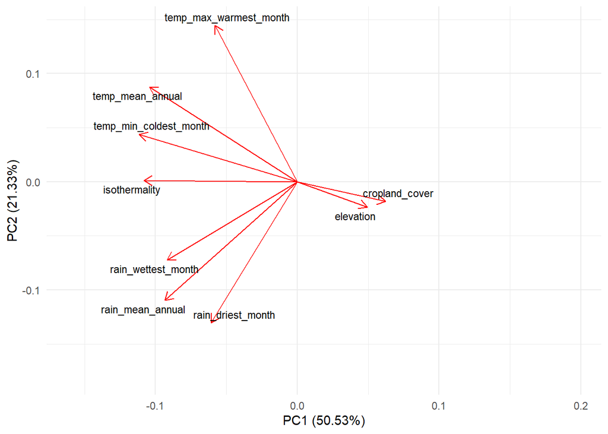

Principal component analysis (PCA) of environmental and climactic variables. The axes of the PCA explain 71.86% of the variance present in the data set. The length of each line indicates the variance described by that value (longer length = greater variance) while the angle between two lines details how correlated the variables are (0 degrees is a correlation of 1, 90 degress is a correlation of 0, 180 degrees is a correlation of -1.)

#### **Citations**

- 1. Google Earth Engine. https://earthengine.google.com.